# Computing Automobile Fuel Efficiency

Power Required to Keep a Car Moving at a Given Speed

Ruben Sanchez Ramirez

February 19, 2021

### **Some Background**

One of the equations used to compute automobile fuel efficiency is as follows this is the power required to keep a car moving at a given speed is as follows:

$Pb=crolling∗m∗g∗V + \frac{1}{2} ∗A∗pair ∗cdrag ∗V^3$

where crolling and cdrag are rolling and aerodynamic resistive coefficients, typical values are 0.015 and 0.3, respectively.

- V: is vehicle speed (assuming no headwind) in m/s (or mps)
- m: is vehicle mass in kg • A is surface area of car (m2)
- g: is acceleration due to gravity (9.8m/s2)
- p_air: is density of air (1.2kg/m3)
- Pb: is power in Watts

Write a function to compute power, given a truck of m=31752 kg (parameters for a heavy truck) for a range of different highway speeds (30 m/s, 80 km/hr, 120 km/hr, 40 km/hr )

### **Calculating power**

#### Contract:

*Input*: vehicle mass in kg (m), vehicle speed in m/s (V) *Output*: power in watts (Pb) *Parameters*: c_rolling (rolling coefficient), g (acceleration due to gravity), A (surface area of vehicle), p_air (air density), and c_drag (aerodynamic resistive coefficient)

#### What will the function do?

Compute the power required to keep a car moving at a given speed, as a proxy for automobile fuel efficiency, using the following equation - *body* of the function

$Pb = c_rolling * m * g * V + \frac{1}{2} * A *p_air * c_drag * V^3$

Pb is power in watts, c_rolling is a rolling coefficient, m is vehicle mass in kg, g is acceleration due to gravity, V is vehicle speed in m/s, A is surface area of vehicle in m^2, p_air is air density, and c_drag is an aerodynamic resistive coefficient.

#### Typical values for:

- $c_{rolling} = 0.015$
- $c_{drag} = 0.3$
- $g = 9.8m/s^2$
- $A = 9m^2$
- $p_{air} = 1.2mg/m^3$

#### Compute power given:

m = 31752 kg  
range of vehicle speeds (30 m/s, 80 km/hr, 120 km/hr, 40 km/hr)  
Unit conversions: km/hr to m/s, 1 km = 1000m, 1 hr = 3600 s, 1 km/hr = 0.277778 m/s  
compute power for a vehicle that is only 75% of the mass of the first vehicle

| speed | power_watts | power_watts_75 |
| --- | --- | --- |
| 11.112 | 54088.5 | 41122.07 |
| 22.224 | 121513.5 | 95580.67 |
| 30.000 | 183766.3 | 148759.74 |
| 33.336 | 215611.6 | 176712.34 |

#### Power as Function of Speed

plot power as a function of speed and add a second line to the graph that shows power for a vehicle that is only 75% of the mass of the first vehicle

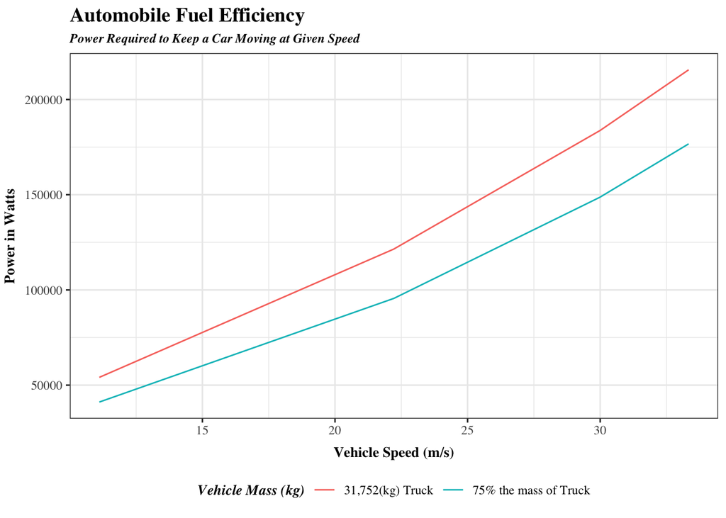